# Average Utilization vs Revenue-Weighted Service Optimization

Objective-to-objective comparison in the 3×3 patient-behavior factorial experiment

This report asks the same core question as the earlier objective-comparison report:

> **For the same clinic background and the same policy regime, what changes when the optimizer targets total throughput versus weighted Class 1 service?**

The comparison is therefore **objective-to-objective**, not policy-to-baseline.

# 1 Objective and comparison design

The current 3×3 factorial experiment optimizes two objectives:

1. **Average utilization**, which gives the same value to a completed Class 1 and Class 2 visit.
2. **Priority-weighted utilization**, which gives a completed Class 1 visit twice the value of a Class 2 visit.

The weighted metric is

$$W_2=\frac{2Y_1+Y_2}{2M},$$

where $Y_1$ and $Y_2$ are completed Class 1 and Class 2 visits and $M$ is measured appointment capacity.

Within a clinic background, maximizing $W_2$ is ranking-equivalent to maximizing

$$R_2=2Y_1+Y_2.$$

Thus this is the **$\alpha=2$ revenue-weighted service comparison**. Unlike the earlier report, the current factorial search does not independently optimize $\alpha=1.3$ and $\alpha=1.6$; the weighted objective actually searched in this experiment is the 2× Class 1 objective.

For each background and policy regime:

1. the average-utilization optimizer selects its best policy cell on the five search seeds;
2. the 2× Class 1 weighted optimizer independently selects its best policy cell;
3. both frozen cells are evaluated on the same ten independent evaluation seeds;
4. every result below is computed as

$$\text{weighted-optimal outcome}
-
\text{average-utilization-optimal outcome}.$$

This matched design isolates the effect of **changing the optimization objective** while holding the clinic background and policy family fixed.

# 2 3×3 patient-behavior design

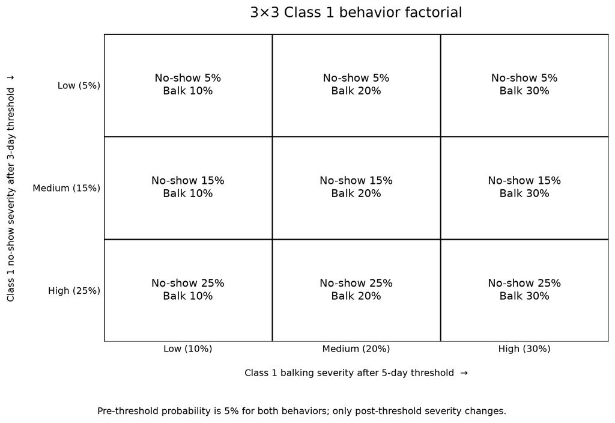

The current Class 1 behavior factorial.

The figure contains the complete Class 1 3×3 design:

- no-show threshold fixed at **3 days**;
- post-threshold no-show probability = **5%, 15%, 25%**;
- balking threshold fixed at **5 days**;
- post-threshold balking probability = **10%, 20%, 30%**;
- the pre-threshold probability is **5%** for both behaviors.

Class 2 is held fixed throughout:

| Class 2 parameter | Fixed value |
| --- | --- |
| No-show | 5% before day 14; 15% after day 14 |
| Balking | 5% before day 16; 15% after day 16 |
| Cancellation | 20% |

Other problem parameters:

| Parameter | Values |
| --- | --- |
| Demand-to-capacity ratio, $\rho$ | 1.2, 1.4, 1.7, 2.0, 2.5; 3.0 retained outside headline range |
| Class 1 share | 0.1, 0.3, 0.5, 0.7, 0.9 |
| Daily capacity | 30, 50 |
| Headline range | $\rho\le2.5$ |
| Search seeds | 5 paired |
| Independent evaluation seeds | 10 paired |

Policy regimes remain:

| Policy | Horizon | Reservations |
| --- | --- | --- |
| Horizon only | Optimized over 2–26 days | None |
| Reservation only | Effectively open horizon | Quantity/window optimized |
| Both flexible | Optimized over 2–26 days | Quantity/window optimized |

# 3 Orientation: what changes when the objective switches?

The table below is intentionally only a compact orientation. The rest of the report dissects these effects by **no-show severity, balking severity, demand, policy, and Class 1 share** rather than relying on one pooled median.

Table 1: Matched change from the average-utilization-optimal cell to the 2× Class 1 weighted-optimal cell.

| Policy | Weighted utilization | Average utilization | Class 1 served rate | Class 2 served rate |
| --- | --- | --- | --- | --- |
| Both flexible | +0.99 pp | -0.04 pp | +3.48 pp | -4.09 pp |
| Horizon only | +0.00 pp | +0.00 pp | +0.00 pp | +0.00 pp |
| Reservation only | +0.69 pp | -0.03 pp | +1.96 pp | -2.85 pp |

The key question is not simply whether the weighted objective is larger—it is optimized to be larger. The substantive questions are:

- **Does it gain weighted service by increasing total throughput or by changing who receives service?**
- **Which patient behaviors make the objective switch consequential?**
- **Does no-show severity affect the objective tradeoff differently from balking severity?**
- **Which policy lever—horizon or reservations—actually changes when Class 1 is given twice the value?**
- **When is the additional Class 1 access obtained with little Class 2 harm, and when is the tradeoff strongly redistributive?**

# 4 Weighted-service gain across the 3×3 behavior design

For these figures:

- x-axis = **balking severity**;
- separate line/marker styles = **no-show severity**;
- separate figure = **policy regime**.

This preserves the factorial structure instead of averaging all nine behavior scenarios together.

## 4.1 Horizon only

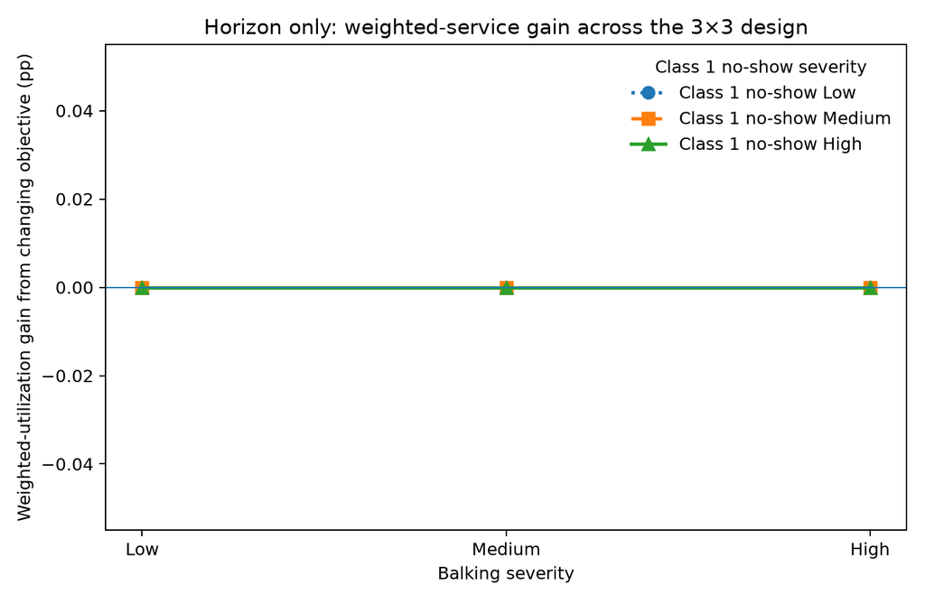

Incremental weighted service under horizon-only when the objective changes.

The slope within each line shows whether changing balking severity alters the value of switching objectives. The vertical separation between lines shows whether changing no-show severity alters that value.

## 4.2 Reservation only

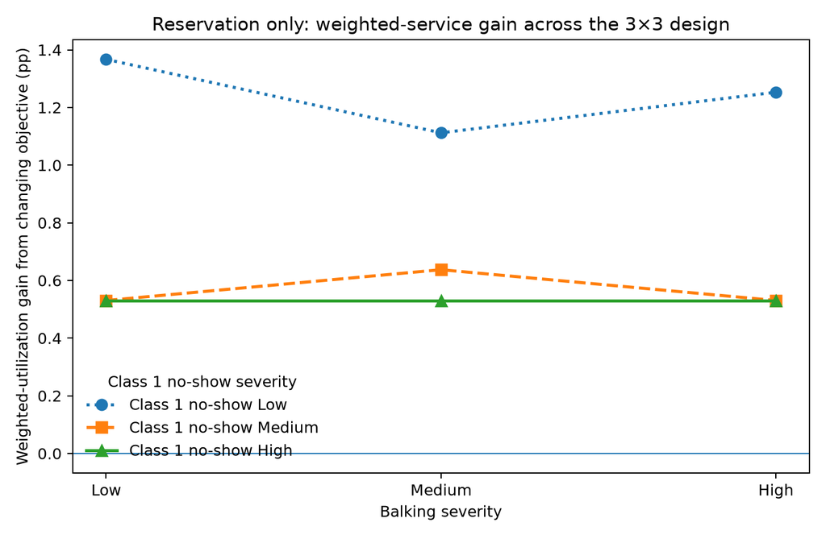

Incremental weighted service under reservation-only across the 3×3 design.

Because reservation-only can explicitly protect Class 1 capacity, this figure shows whether the value of the weighted objective depends on the Class 1 behavioral cell rather than only on the existence of a reservation lever.

## 4.3 Both flexible

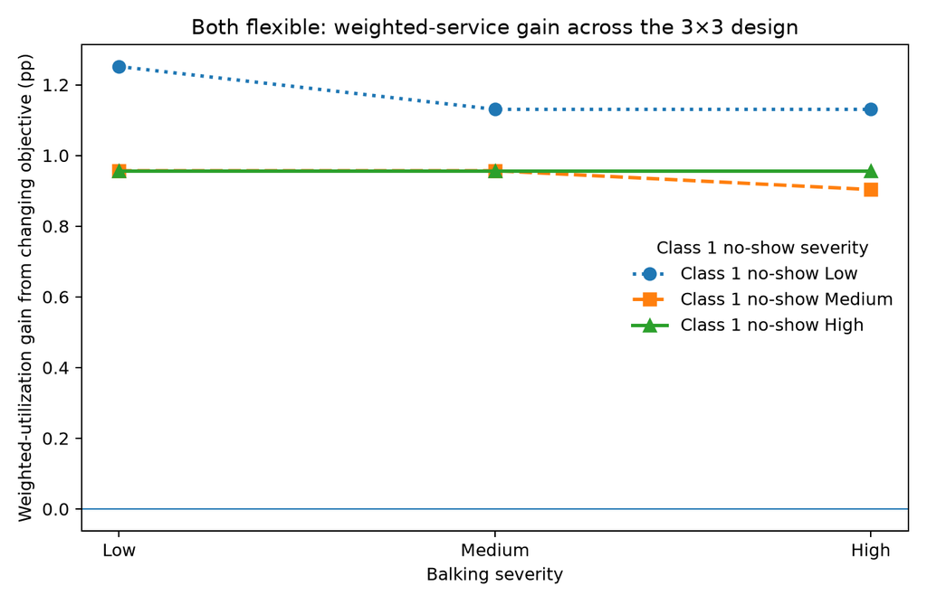

Incremental weighted service under both-flexible across the 3×3 design.

Both-flexible allows the optimizer to change both delay exposure and protected capacity. Comparing this figure with horizon-only and reservation-only identifies which lever makes the objective switch consequential.

# 5 Does weighted optimization sacrifice throughput?

A weighted objective can improve $W_2$ either by finding additional completed service or by replacing some Class 2 service with Class 1 service. The figure below compresses the throughput comparison into a single behavior-by-behavior view.

- rows = **Class 1 no-show severity**
- columns = **Class 1 balking severity**
- bars inside each cell = **policy regime**
  - **H** = Horizon only
  - **R** = Reservation only
  - **B** = Both flexible

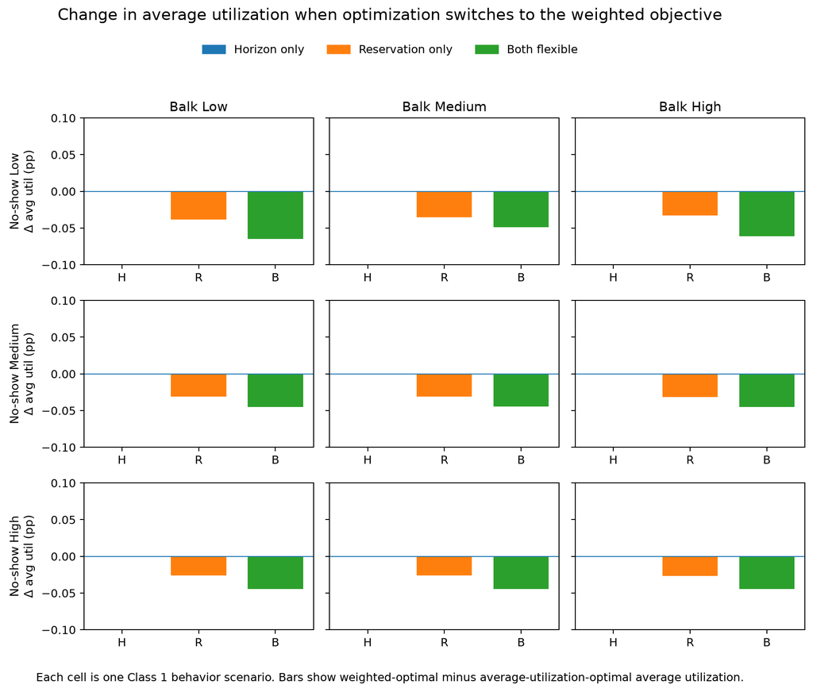

Average-utilization effect of switching objectives, shown jointly for all three policies across the 3×3 behavior design.

Bars near zero indicate that the weighted objective gains value mainly by **changing who is served** rather than by increasing total completed visits. A negative bar means the weighted-optimal cell sacrifices some ordinary average utilization relative to the average-utilization-optimal counterpart.

# 6 Access is the main margin of adjustment

The next figures show Class 1 and Class 2 served-rate changes together within each policy.

- **Blue = Class 1 served-rate outcome**
- **Orange = Class 2 served-rate outcome**
- marker/line style = **Class 1 no-show severity**
- x-axis = **Class 1 balking severity**

**Class 2 behavior is fixed throughout.** The low/medium/high labels attached to both colored outcome lines refer to the **Class 1 behavior scenario** under which the Class 1 or Class 2 served rate is measured; they do not indicate different Class 2 behavior levels.

This makes it possible to see both the **Class 1 behavioral cell** and the **direction of redistribution** in one figure.

## 6.1 Horizon only

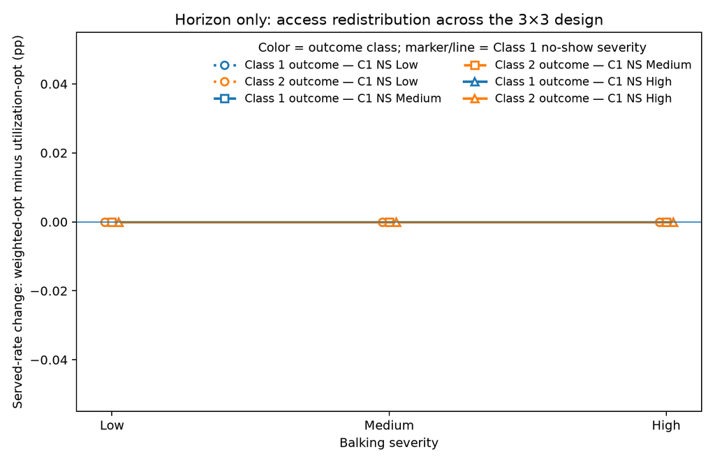

Class-specific objective-switch effects under horizon-only.

## 6.2 Reservation only

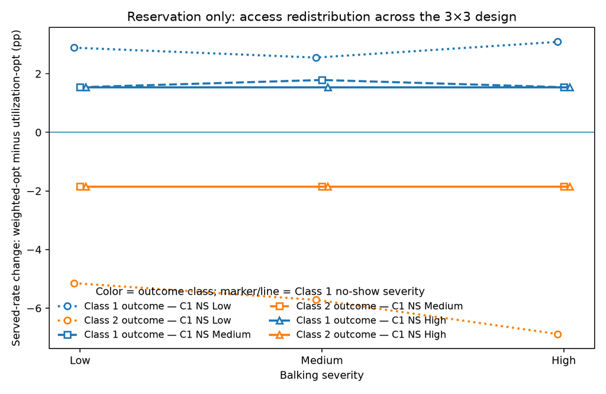

Class-specific objective-switch effects under reservation-only.

## 6.3 Both flexible

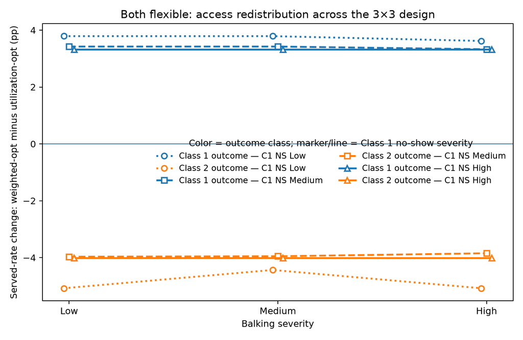

Class-specific objective-switch effects under both-flexible.

A pattern of positive Class 1 changes paired with negative Class 2 changes indicates that weighting changes **who occupies scarce capacity**, even when total utilization changes little.

# 7 Demand: when do the behavioral differences become active?

Each policy now has one demand figure containing all six sensitivity profiles:

- **blue = no-show**
- **orange = balking**
- circle/dotted = low
- square/dashed = medium
- triangle/solid = high

For a no-show line, each point averages across the three balking levels. For a balking line, each point averages across the three no-show levels.

## 7.1 Horizon only

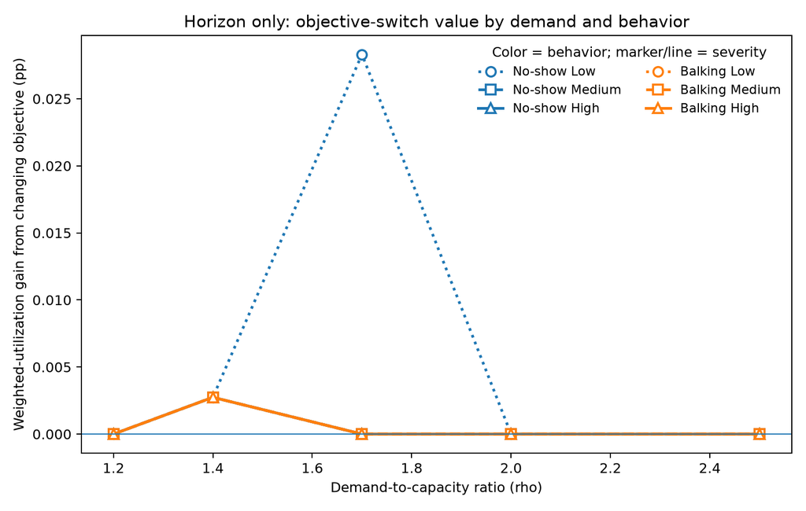

Objective-switch weighted-service value by demand and behavior under horizon-only.

## 7.2 Reservation only

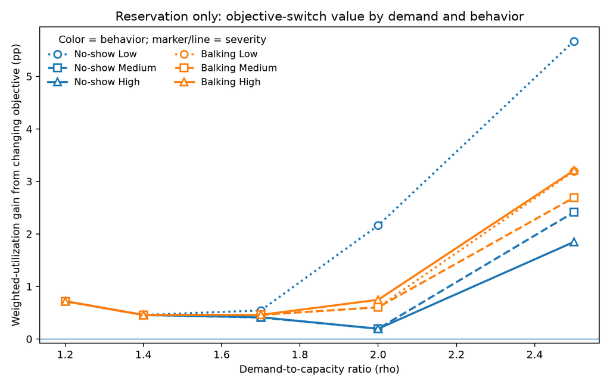

Objective-switch weighted-service value by demand and behavior under reservation-only.

## 7.3 Both flexible

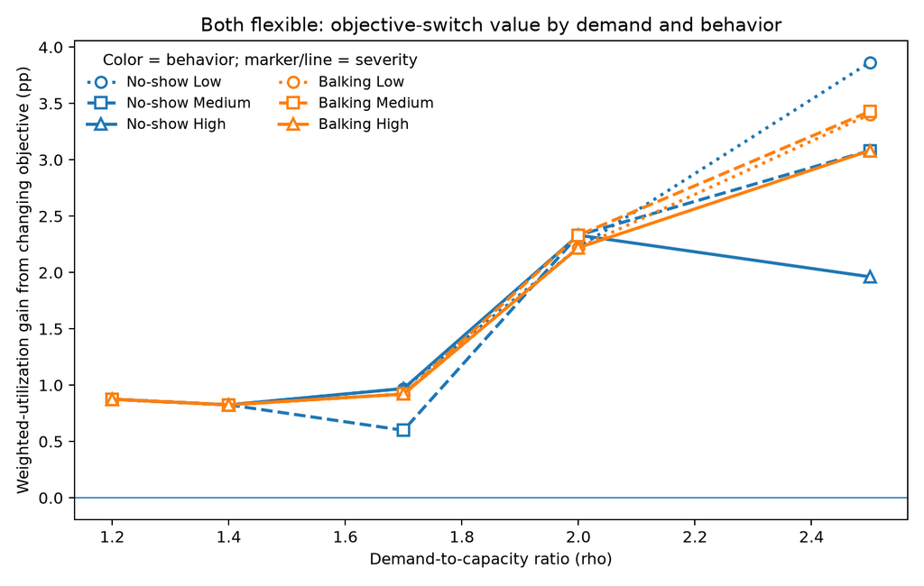

Objective-switch weighted-service value by demand and behavior under both-flexible.

These figures show whether weighting begins to matter only after congestion exposes patients to the 3-day no-show or 5-day balking thresholds.

# 8 Scenario-by-scenario access tradeoff

The scatterplots retain every headline-range background rather than reducing the comparison to a single average.

- **x-axis = change in Class 1 served rate (percentage points)**
- **y-axis = change in Class 2 served rate (percentage points)**

So the y-axis is **not** the Class 2 service level itself; it is the **difference** between the weighted-optimal and average-utilization-optimal cells. Dashed lines mark the ±0.5 percentage-point practical band.

## 8.1 Horizon only

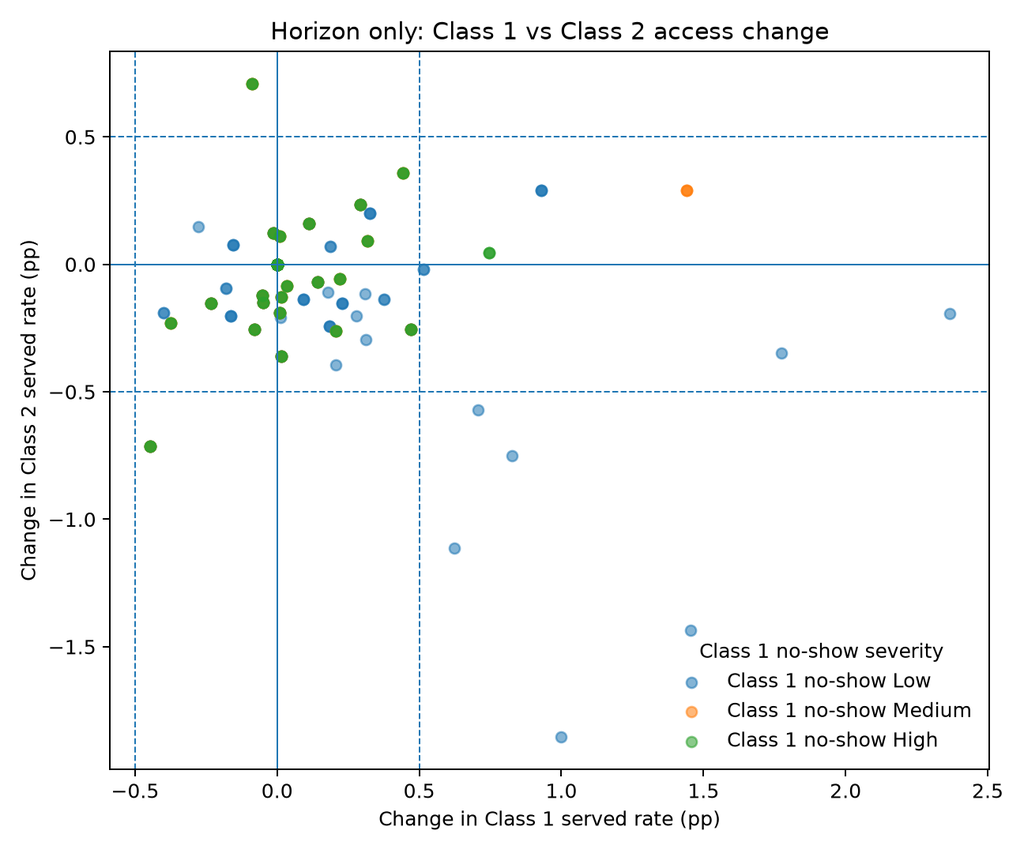

Each dot is a clinic background. Coordinates are weighted-optimal minus average-utilization-optimal served-rate changes.

## 8.2 Reservation only

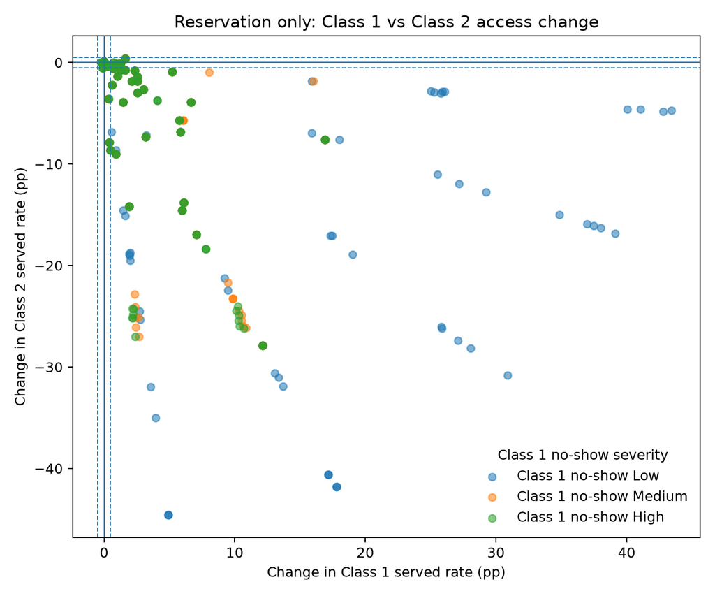

Reservation-only Class 1 versus Class 2 objective-switch effects.

## 8.3 Both flexible

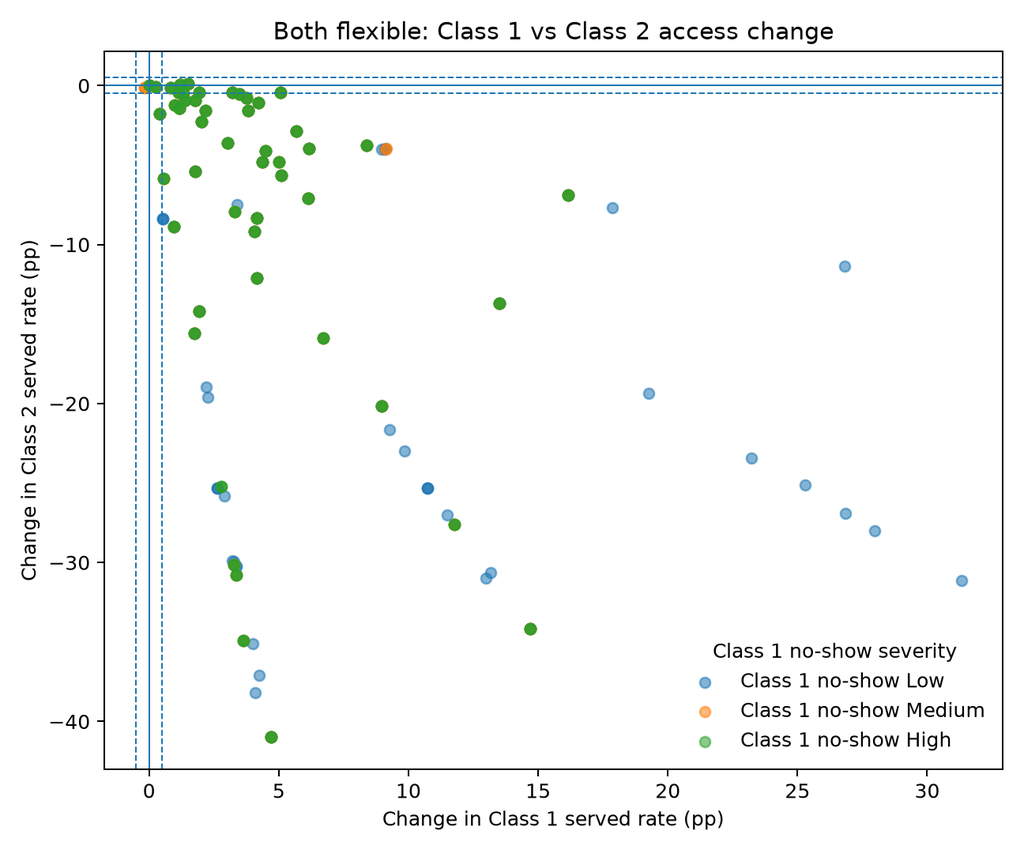

Both-flexible Class 1 versus Class 2 objective-switch effects.

The scatterplots answer directly whether weighting creates:

- higher Class 1 access with little Class 2 change;
- higher Class 1 access with substantial Class 2 displacement;
- or little difference from the average-utilization solution.

# 9 When does weighted optimization produce win-win or win/neutral access?

Using the same **±0.5 percentage-point practical band** as in the average-utilization report, the matched objective-switch result is classified as:

- **Win-win:** both Class 1 and Class 2 served rates increase by at least +0.5 pp, with both 95% confidence intervals above zero;
- **Class 1 win / Class 2 neutral:** Class 1 increases by at least +0.5 pp with a 95% confidence interval above zero, while the entire Class 2 95% confidence interval stays inside ±0.5 pp;
- **Class 2 win / Class 1 neutral:** the symmetric case for Class 2.

Table 2: Win-win and win/neutral cases under weighted optimization relative to the average-utilization-optimal counterpart.

| Policy | Case type | Cases | Share of backgrounds |
| --- | --- | --- | --- |
| Both flexible | C1 win / C2 neutral | 18 | 4.0% |
| Horizon only | C1 win / C2 neutral | 4 | 0.9% |
| Horizon only | C2 win / C1 neutral | 6 | 1.3% |
| Reservation only | C1 win / C2 neutral | 16 | 3.6% |

### 9.0.1 Where do the favorable cases occur?

Rather than listing every favorable background, the next table summarizes the **behavior-severity cells** in which win-win or win/neutral cases occur. The percentage is the share of all favorable cases for that policy that fall in that Class 1 no-show × balking cell.

Table 3: Behavior-severity concentration of win-win and win/neutral cases.

| Policy | Case type | No-show severity | Balking severity | Cases | Share of favorable cases |
| --- | --- | --- | --- | --- | --- |
| Both flexible | C1 win / C2 neutral | High | High | 2 | 11.1% |
| Both flexible | C1 win / C2 neutral | High | Low | 2 | 11.1% |
| Both flexible | C1 win / C2 neutral | High | Medium | 2 | 11.1% |
| Both flexible | C1 win / C2 neutral | Low | High | 2 | 11.1% |
| Both flexible | C1 win / C2 neutral | Low | Low | 2 | 11.1% |
| Both flexible | C1 win / C2 neutral | Low | Medium | 2 | 11.1% |
| Both flexible | C1 win / C2 neutral | Medium | High | 2 | 11.1% |
| Both flexible | C1 win / C2 neutral | Medium | Low | 2 | 11.1% |
| Both flexible | C1 win / C2 neutral | Medium | Medium | 2 | 11.1% |
| Horizon only | C1 win / C2 neutral | High | High | 1 | 10.0% |
| Horizon only | C1 win / C2 neutral | High | Low | 1 | 10.0% |
| Horizon only | C1 win / C2 neutral | High | Medium | 1 | 10.0% |
| Horizon only | C1 win / C2 neutral | Low | High | 1 | 10.0% |
| Horizon only | C2 win / C1 neutral | High | High | 1 | 10.0% |
| Horizon only | C2 win / C1 neutral | High | Low | 1 | 10.0% |
| Horizon only | C2 win / C1 neutral | High | Medium | 1 | 10.0% |
| Horizon only | C2 win / C1 neutral | Medium | High | 1 | 10.0% |
| Horizon only | C2 win / C1 neutral | Medium | Low | 1 | 10.0% |
| Horizon only | C2 win / C1 neutral | Medium | Medium | 1 | 10.0% |
| Reservation only | C1 win / C2 neutral | High | High | 3 | 18.8% |
| Reservation only | C1 win / C2 neutral | High | Low | 3 | 18.8% |
| Reservation only | C1 win / C2 neutral | High | Medium | 3 | 18.8% |
| Reservation only | C1 win / C2 neutral | Medium | High | 3 | 18.8% |
| Reservation only | C1 win / C2 neutral | Medium | Low | 3 | 18.8% |
| Reservation only | C1 win / C2 neutral | Medium | Medium | 1 | 6.2% |

### 9.0.2 Similarities within each policy and favorable case type

The next table identifies the **most common severity and clinic conditions** within each policy × case-type group. Percentages in parentheses show the share of that group’s favorable cases with the listed value. A high percentage indicates genuine clustering; a low percentage means the cases are spread across multiple conditions.

Table 4: Most common characteristics among win-win and win/neutral cases.

| Policy | Case type | Cases | Most common no-show | Most common balking | Most common rho | Most common Class 1 share | Most common capacity |
| --- | --- | --- | --- | --- | --- | --- | --- |
| Both flexible | C1 win / C2 neutral | 18 | High, Low, Medium (33%) | High, Low, Medium (33%) | 2.0, 2.5 (50%) | 0.1 (100%) | 50 (100%) |
| Horizon only | C1 win / C2 neutral | 4 | High (75%) | High (50%) | 1.7 (75%) | 0.1 (100%) | 30 (75%) |
| Horizon only | C2 win / C1 neutral | 6 | High, Medium (50%) | High, Low, Medium (33%) | 2.5 (100%) | 0.9 (100%) | 50 (100%) |
| Reservation only | C1 win / C2 neutral | 16 | High (56%) | High, Low (38%) | 2.5 (62%) | 0.1 (100%) | 50 (69%) |

**Both flexible — C1 win / C2 neutral:** common features are rho 2.0/2.5 (9/18); Class 1 share 0.1 (18/18); capacity 50 (18/18).

**Horizon only — C1 win / C2 neutral:** common features are no-show High (3/4); balking High (2/4); rho 1.7 (3/4); Class 1 share 0.1 (4/4); capacity 30 (3/4).

**Horizon only — C2 win / C1 neutral:** common features are no-show High/Medium (3/6); rho 2.5 (6/6); Class 1 share 0.9 (6/6); capacity 50 (6/6).

**Reservation only — C1 win / C2 neutral:** common features are no-show High (9/16); rho 2.5 (10/16); Class 1 share 0.1 (16/16); capacity 50 (11/16).

This presentation emphasizes **what the favorable cases have in common** rather than enumerating individual backgrounds. Class 2 behavior remains fixed throughout; low/medium/high severity always refers to **Class 1** no-show or balking behavior.

# 10 Class 1 population share changes the access tradeoff

The previous objective-comparison analysis showed that the size of the priority population changes how costly it is to redirect access. The new factorial allows that question to be examined while retaining no-show severity.

## 10.1 Reservation only

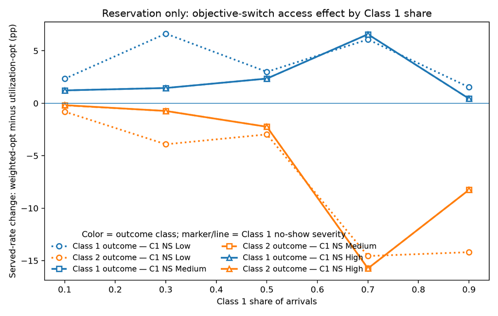

Reservation-only access effect by Class 1 share and no-show severity.

## 10.2 Both flexible

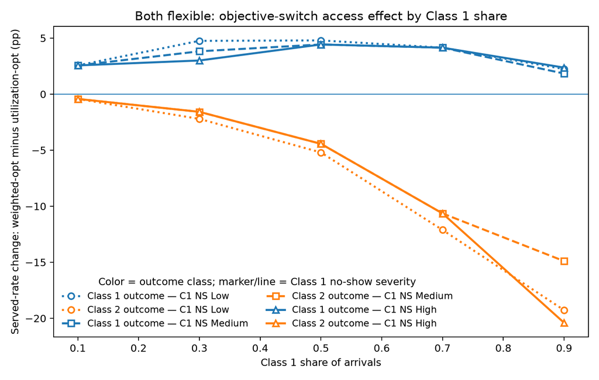

Both-flexible access effect by Class 1 share and no-show severity.

These figures distinguish:

- the **priority-population size effect** on the x-axis;
- **Class 1 versus Class 2 served-rate outcomes** by color;
- **Class 1 no-show severity** by marker and line style.

Again, Class 2 behavior is held fixed; the low/medium/high line styles describe the **Class 1 no-show scenario** in which the Class 2 outcome is observed.

This avoids treating all Class 1 patient-behavior scenarios as interchangeable when assessing the access cost of revenue weighting.

# 11 Clinic-facing interpretation

Use the figures above in this order:

1. **Start with the 3×3 weighted-service figures.** Identify which behavioral cells make changing the objective consequential.
2. **Check the combined average-utilization bar grid.** If weighted value rises while the bars stay near zero, the gain is redistribution rather than additional throughput.
3. **Inspect Class 1 and Class 2 together.** Determine whether the weighted gain is obtained with a neutral Class 2 effect or with substantial displacement.
4. **Use the demand figures to identify when the tradeoff activates.**
5. **Check the win-win / win-neutral summaries** to see whether favorable access cases occur and which Class 1 severity and clinic conditions they have in common.
6. **Finally condition on Class 1 share.** The same Class 1 gain can imply very different Class 2 costs depending on how large the priority population is.

The objective choice should therefore be interpreted as a **clinic preference decision**. Average utilization is appropriate when total completed service is the primary goal. The weighted objective is appropriate only when the clinic intentionally assigns additional value to Class 1 service and accepts the access consequences identified in the detailed behavioral and demand scenarios.

Primary data inputs:

- `full_run_summaries/patient_behavior_factorial_3_5/release/selected_policy_seed_outcomes.csv`
- `full_run_summaries/patient_behavior_factorial_3_5/release/selected_policy_outcomes.csv`

All objective-switch results are matched within the **same background, policy regime, and independent evaluation seed**.